# Intro to Data Visualization with Python Part II

## 01 import libraries

```python
import pandas as pd
import numpy as np
import os
import matplotlib.pyplot as plt
import seaborn as sns
import scipy
```

## 02 create path

```python
path = r'C:\Users\rober_fjs0dbr\OneDrive\Documents\CF Coursework\Python Fundamentals for Data Analysts\11-04-2022 Instacart Basket Analysis'
```

```python
path
```

```
'C:\\Users\\rober_fjs0dbr\\OneDrive\\Documents\\CF Coursework\\Python Fundamentals for Data Analysts\\11-04-2022 Instacart Basket Analysis'
```

## 03 import data

```python
# import order_prods_merged_v0 pickle as dataframe
orders_products_all = pd.read_pickle(os.path.join(path, '02 Data', 'Prepared Data', 'orders_products_all.pkl'))
```

```python
orders_products_all.shape
```

```
(9721098, 31)
```

```python
orders_products_all.head(5)
```

|  | order_id | user_id | order_number | orders_day_of_week | order_hour_of_day | days_since_prior_order | product_id | add_to_cart_order | reordered | product_name | ... | frequency_flag | first_name | last_name | gender | state | age | date_joined | number_of_dependants | fam_status | income |
| --- | --- | --- | --- | --- | --- | --- | --- | --- | --- | --- | --- | --- | --- | --- | --- | --- | --- | --- | --- | --- | --- |
| 0 | 2539329 | 1 | 1 | 2 | 8 | NaN | 196.0 | 1.0 | 0.0 | Soda | ... | Non-frequent customer | Linda | Nguyen | Female | Alabama | 31 | 2/17/2019 | 3 | married | 40423 |
| 1 | 473747 | 1 | 3 | 3 | 12 | 21.0 | 196.0 | 1.0 | 1.0 | Soda | ... | Non-frequent customer | Linda | Nguyen | Female | Alabama | 31 | 2/17/2019 | 3 | married | 40423 |
| 2 | 2254736 | 1 | 4 | 4 | 7 | 29.0 | 196.0 | 1.0 | 1.0 | Soda | ... | Non-frequent customer | Linda | Nguyen | Female | Alabama | 31 | 2/17/2019 | 3 | married | 40423 |
| 3 | 550135 | 1 | 7 | 1 | 9 | 20.0 | 196.0 | 1.0 | 1.0 | Soda | ... | Non-frequent customer | Linda | Nguyen | Female | Alabama | 31 | 2/17/2019 | 3 | married | 40423 |
| 4 | 2539329 | 1 | 1 | 2 | 8 | NaN | 12424.0 | 3.0 | 0.0 | Original Beef Jerky | ... | Non-frequent customer | Linda | Nguyen | Female | Alabama | 31 | 2/17/2019 | 3 | married | 40423 |

5 rows × 31 columns

# Task II

## 03 You need to provide the Instacart senior stakeholders with descriptive findings about sales. Create a histogram of the “order_hour_of_day” column.

##### In a markdown cell beneath your histogram, describe what the histogram demonstrates.

```python
# print sorted frequencies of 'order_hour_of_day'

orders_products_all['order_hour_of_day'].value_counts().sort_index()
```

```
0      65646
1      34530
2      20712
3      15361
4      15924
5      26442
6      87193
7     268333
8     515550
9     736270
10    827426
11    820235
12    785636
13    798535
14    806805
15    798388
16    760585
17    627507
18    490559
19    377581
20    292601
21    238620
22    190580
23    120079
Name: order_hour_of_day, dtype: int64
```

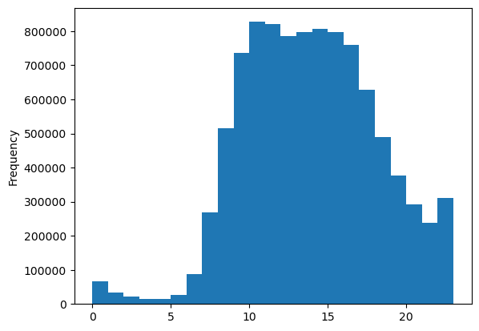

```python
# create a histogram of the 'order_hour_of_day' column

orders_products_all['order_hour_of_day'].plot.hist(bins = 23)
```

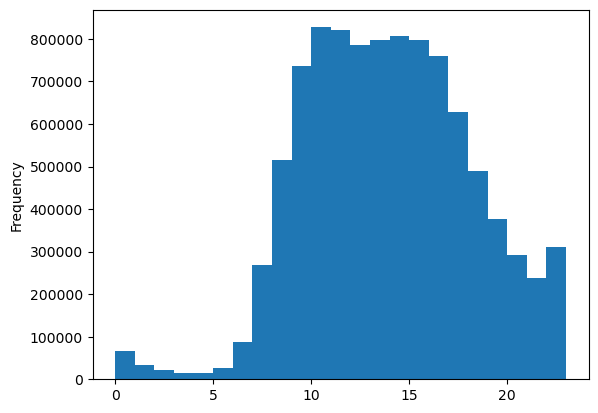

```python
# save 'order_hour_of_day' bar chart as hour_hist

hour_hist = orders_products_all['order_hour_of_day'].plot.hist(bins = 23)
```

```python
# export histogram

hour_hist.figure.savefig(os.path.join(path, '04 Analysis','Visualizations', 'hour_hist.png'))
```

This histogram demonstates that sales peak between 10 AM and 5 PM. They are lowest from 12 AM to 6 AM.

## 04 The marketing team is curious about the distribution of orders among customers in terms of loyalty. Create a bar chart from the “loyalty_flag” column.

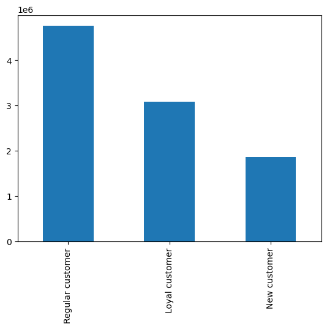

```python
# create bar chart displaying frequency of each value from 'loyalty' variable

orders_products_all['loyalty_flag'].value_counts().plot.bar()
```

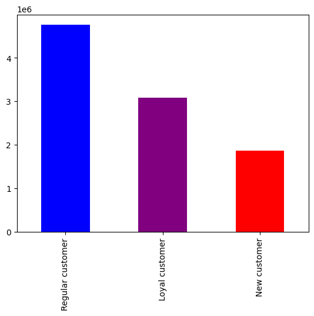

```python
# create bar chart with color displaying frequency of each value from 'loyalty_flag' variable

orders_products_all['loyalty_flag'].value_counts().plot.bar(color =['blue', 'purple', 'red'])
```

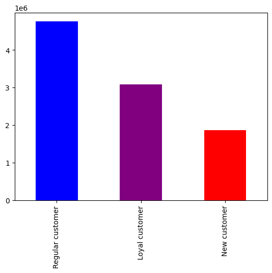

```python
# save as 'loyalty flag' bar chart as loyal_bar

loyal_bar = orders_products_all['loyalty_flag'].value_counts().plot.bar(color =['blue', 'purple', 'red'])
```

```python
# export bar chart

loyal_bar.figure.savefig(os.path.join(path, '04 Analysis','Visualizations', 'loyal_bar.png'))
```

## 05 Check whether there’s a difference in expenditure (the “prices” column) depending on the hour of the day. (Hint: To check this, you need to use an accurate sample for your line chart!)

#### * no sample needed; 30% random sample applied to orders_products_all to resolve memory issues

```python
# rename 'orders_day_of_week' to 'day_of_week_order_placed'
# rename 'order_hour_of_day' to 'hour_of_day_order_placed'
# rename 'number_of_dependants' to 'number_of_dependents'

orders_products_all.rename(columns = {'orders_day_of_week' : 'day_of_week_order_placed', 'order_hour_of_day' : 'hour_of_day_order_placed', 'number_of_dependants' : 'number_of_dependents'}, inplace = True)
```

```python
# reduce dataframe orders_products_all to only include columns 'prices' and 'hour_of_day_order_placed'

hour_price = orders_products_all[['hour_of_day_order_placed','prices']]
```

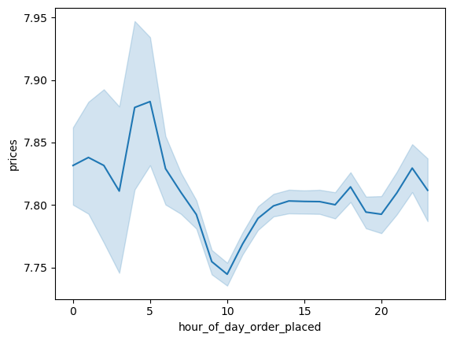

```python
# create line chart of orders_products_all dataframe where
# x axis is 'hour_of_day_order_placed' and y axis is 'prices'

hour_price_line = sns.lineplot(data = hour_price, x = 'hour_of_day_order_placed',y = 'prices')
```

```python
# export hour_price_line chart

hour_price_line.figure.savefig(os.path.join(path, '04 Analysis','Visualizations', 'hour_price_line.png'))
```

Prices of orders peak around 4-5 AM and are lowest from 9 to 11 AM.

## 06 Now that you have information about customers, you need to conduct some exploratory analysis of customer demographics to inform the targeted marketing campaigns. First, determine whether there’s a connection between age and family situation by creating a line chart exploring the connections between age and number of dependents:

##### In a markdown cell beneath your line chart, describe what the line chart shows.

```python
# reduce dataframe orders_products_all to only include columns 'age' and 'hour_of_day_order_placed'

age_dependents = orders_products_all[['age','number_of_dependents']]
```

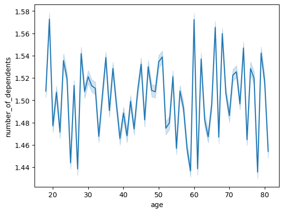

```python
# create line chart of orders_products_all dataframe where
# x axis is 'age' and y axis is 'number_of_dependents'

age_dependents_line = sns.lineplot(data = age_dependents, x = 'age',y = 'number_of_dependents')
```

Based on the above line chart exploring the is no clear connection between a customers age and their number of dependents.

```python
# export hour_price_line chart

age_dependents_line.figure.savefig(os.path.join(path, '04 Analysis','Visualizations', 'age_dependents_line.png'))
```

## 07 You’ll also need to explore whether there’s a connection between age and spending power (income). To visualize this relationship, create a scatterplot using the sns.scatterplot() function.

##### In a markdown cell beneath your scatterplot, describe what the scatterplot shows.

```python
# reduce dataframe orders_products_all to only include columns 'age' and 'income'

age_income = orders_products_all[['age','income']]
```

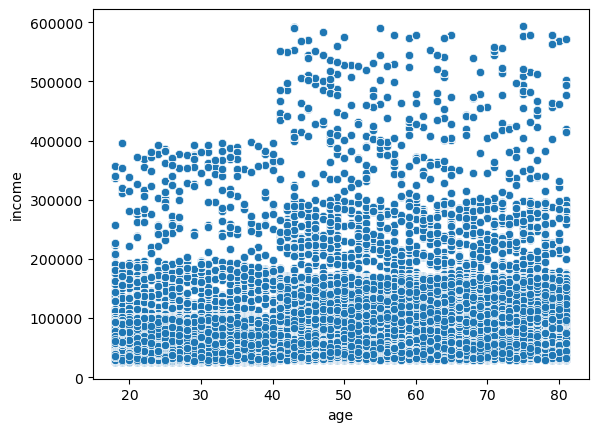

```python
# create scatterplot of comparing 'age' to 'income'

sns.scatterplot(x = 'age', y = 'income',data = orders_products_all)
```

Based on the above scatterplot it is hard to see too strong a correlation between age and income. However, the highest earners begin to occur after the age of 40.